# CSE 252A (Computer Vision I) · Fall 2020 · Assignment 0

### Instructor: David Kriegman

### Assignment published on Monday, October 5, 2020

### Due on Wednesday, October 14, 2020 at 11:59 pm Pacific Time

## Instructions

- Review the academic integrity and collaboration policies on Canvas. This assignment must be completed individually.
- All solutions must be written in this notebook. Programming aspects of the assignment must be completed using Python (preferably 3.6+).
- If you want to modify the skeleton code, you may do so. The existing code is merely intended to provide you with a framework for your solution.
- You may use Python packages for basic linear algebra (e.g. simple operations from NumPy or SciPy), but you may **not** use packages that directly solve the problem. If you are unsure about using a specific package or function, please ask the instructor and teaching assistants for clarification.
- You must submit, through Gradescope, both (1) this notebook exported as a PDF **and** (2) this notebook as an `.ipynb` file. You must mark every problem in the PDF on Gradescope. If you do not submit both the `.pdf` and `.ipynb`, and/or if you do not mark every problem in the PDF on Gradescope, you may receive a penalty.
- It is highly recommended that you begin working on this assignment early.
- **Late policy:** Assignments submitted late will receive a 10% grade reduction for each day late (e.g. an assignment submitted an hour after the due date will receive a 10% penalty, an assignment submitted 10 hours after the due date will receive a 10% penalty, and an assignment submitted 28 hours after the due date will receive a 20% penalty). Assignments will not be accepted 72 hours after the due date. If you require an extension (for personal reasons only), you must request one as far in advance as possible. Extensions requested close to or after the due date will only be granted for clear emergencies or clearly unforeseeable circumstances.

Welcome to CSE 252A: Computer Vision I! This course will give you a comprehensive introduction to computer vision, covering topics such as low-level vision, inference of 3D properties from images, and object recognition. In this class, we will utilize a variety of tools which may require some initial configuration. To ensure a smooth transition into later assignments, we'll get you set up with most of those course tools in this assignment. You will also practice some basic image manipulation techniques.

When you are finished, you will need to export this Jupyter notebook as a PDF, and submit both that PDF and this `.ipynb` file to Gradescope.

## Piazza, Gradescope and Python

**Piazza**

Go to [Piazza](https://piazza.com/ucsd/fall2020/cse252a) and sign up for the class using your `ucsd.edu` email account. You'll be able to ask the professor, the TAs, and your classmates questions on Piazza. Class announcements will also be made using Piazza, so make sure you check your email or Piazza frequently.

**Gradescope**

See the Piazza post on how to add CSE 252A in Gradescope. You will be required to submit each assignment to Gradescope for grading. Make sure you mark the pages in the PDF that are associated with each question.

**Python**

We will use the Python programming language for all assignments in this course, in tandem with a few popular libraries (e.g. NumPy and matplotlib). Assignments will be given in the form of browser-based Jupyter notebooks, such as the one you are currently viewing. We expect that many of you will already have some experience with Python and NumPy. If so, great! If not, don't worry (as long as you have *some* programming experience). You can pick it up quickly. If you lack Python knowledge but have previous experience with Matlab, you might want to check out the [NumPy for Matlab users](https://docs.scipy.org/doc/numpy-dev/user/numpy-for-matlab-users.html) page.

The section below will serve as a quick introduction to NumPy and some of the other libraries that we'll use. (Just run through the cells; you don't need to do anything for credit until you get to Problem 1.)

## Getting started with NumPy

NumPy is a fundamental package for scientific computing with Python. It provides a powerful N-dimensional array object as well as functions for working with such arrays.

### Arrays

```python
import numpy as np

array1d = np.array([1,0,0])           # a 1D array

print("1D array :")
print(array1d)
print("Shape :", array1d.shape)       # print the shape of the array

array2d = np.array([[1], [2], [3]])   # a 2D array
print("\n2D array :")
print(array2d)
print("Shape :", array2d.shape)       # print the size of the array; notice the difference

print("\nTranspose 2D :", array2d.T)  # transpose of a 2D array
print("Shape :", array2d.T.shape)

print("\nTranspose 1D :", array1d.T)  # notice how the 1D array did not change after the transpose
print("Shape :", array1d.T.shape)

allzeros = np.zeros([2, 3])           # 2x3 array of zeros
allones =  np.ones([1, 3])            # 1x3 array of ones
identity = np.eye(3)                  # identity matrix
rand3_1 = np.random.rand(3, 1)        # random matrix with values in [0, 1]
arr = np.ones(allones.shape) * 3      # create a matrix from shape

print("\n arr printed")
print(arr)
```

```
1D array :
[1 0 0]
Shape : (3,)

2D array :
[[1]
 [2]
 [3]]
Shape : (3, 1)

Transpose 2D : [[1 2 3]]
Shape : (1, 3)

Transpose 1D : [1 0 0]
Shape : (3,)

 arr printed
[[3. 3. 3.]]
```

### Array Indexing

```python
import numpy as np
array2d = np.array([[1, 2, 3], [4, 5, 6]])  # create a 2d array with shape (2, 3)
print("Access a single element")
print(array2d[0, 2])                        # access an element
array2d[0, 2] = 252                         # a slice of an array is a view into the same data;
print("\nModified a single element")
print(array2d)                              # this will modify the original array

print("\nAccess a subarray")
print(array2d[1, :])                        # access a row (to 1d array)
print(array2d[1:, :])                       # access a row (to 2d array)
print("\nTranspose a subarray")
print(array2d[1, :].T)                      # notice the difference of the dimension of resulting array
print(array2d[1:, :].T)                     # this will be helpful if you want to transpose it later

# Boolean array indexing
# Given a array m, create a new array with values equal to m
# if they are greater than 0, and equal to 0 if they less than or equal 0

array2d = np.array([[3, 5, -2], [50, -1, 0]])
arr = np.zeros(array2d.shape)
arr[array2d > 0] = array2d[array2d > 0]
print("\nBoolean array indexing")
print(arr)
```

```
Access a single element
3

Modified a single element
[[  1   2 252]
 [  4   5   6]]

Access a subarray
[4 5 6]
[[4 5 6]]

Transpose a subarray
[4 5 6]
[[4]
 [5]
 [6]]

Boolean array indexing
[[ 3.  5.  0.]
 [50.  0.  0.]]
```

### Operations on Arrays

**Elementwise Operations**

```python
import numpy as np

a = np.array([[1, 2, 3], [2, 3, 4]], dtype=np.float64)
print(a * 2)                                            # scalar multiplication
print(a / 4)                                            # scalar division
print(np.round(a / 4))
print(np.power(a, 2))
print(np.log(a))

b = np.array([[5, 6, 7], [5, 7, 8]], dtype=np.float64)
print(a + b)                                            # elementwise sum
print(a - b)                                            # elementwise difference
print(a * b)                                            # elementwise product
print(a / b)                                            # elementwise division
```

```
[[2. 4. 6.]
 [4. 6. 8.]]
[[0.25 0.5  0.75]
 [0.5  0.75 1.  ]]
[[0. 0. 1.]
 [0. 1. 1.]]
[[ 1.  4.  9.]
 [ 4.  9. 16.]]
[[0.         0.69314718 1.09861229]
 [0.69314718 1.09861229 1.38629436]]
[[ 6.  8. 10.]
 [ 7. 10. 12.]]
[[-4. -4. -4.]
 [-3. -4. -4.]]
[[ 5. 12. 21.]
 [10. 21. 32.]]
[[0.2        0.33333333 0.42857143]
 [0.4        0.42857143 0.5       ]]
```

**Vector Operations**

```python
import numpy as np

a = np.array([[1, 2], [3, 4]])

print("sum of array")
print(np.sum(a))                # sum of all array elements
print(np.sum(a, axis=0))        # sum of each column
print(np.sum(a, axis=1))        # sum of each row

print("\nmean of array")
print(np.mean(a))               # mean of all array elements
print(np.mean(a, axis=0))       # mean of each column
print(np.mean(a, axis=1))       # mean of each row
```

```
sum of array
10
[4 6]
[3 7]

mean of array
2.5
[2. 3.]
[1.5 3.5]
```

**Matrix Operations**

```python
import numpy as np

a = np.array([[1, 2], [3, 4]])
b = np.array([[5, 6], [7, 8]])
print("matrix-matrix product")
print(a.dot(b))                   # matrix product
print(a.T.dot(b.T))

x = np.array([1, 2])
print("\nmatrix-vector product")
print(a.dot(x))                   # matrix / vector product
print(a @ x)                      # Can also make use of the @ instad of .dot(); requires Python 3.5+
```

```
matrix-matrix product
[[19 22]
 [43 50]]
[[23 31]
 [34 46]]

matrix-vector product
[ 5 11]
[ 5 11]
```

### Matplotlib

Matplotlib is a plotting library. We will use it to show the results in this assignment.

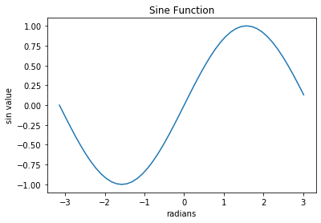

```python
# this line prepares IPython for working with matplotlib
%matplotlib inline

import numpy as np
import matplotlib.pyplot as plt
import math

x = np.arange(-24, 24) / 24. * math.pi
plt.plot(x, np.sin(x))
plt.xlabel('radians')
plt.ylabel('sin value')
plt.title('Sine Function')

plt.show()
```

This brief overview introduces many basic functions from a few popular libraries, but it is far from complete. Check out the documentation for [NumPy](https://docs.scipy.org/doc/numpy/reference/) and [matplotlib](https://matplotlib.org/) to find out more.

## Problem 1: Image Operations and Vectorization (1 point)

Vector operations using NumPy can offer a significant speedup over performing operations iteratively on an image. The problem below will demonstrate the time it takes for both approaches to change the color of quadrants of an image.

The problem reads the image `macaw.jpg` that you will find in the assignment folder. Two functions are then provided as alternatives for performing an operation on the image.

Your job is to follow the code and then fill in the `piazza` function according to instructions on Piazza.

```
Image shape: (640, 640, 3)
```

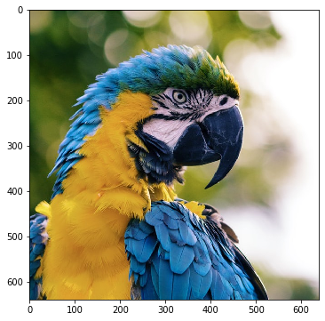

```python
import numpy as np
import matplotlib.pyplot as plt
import copy
import time

%matplotlib inline

img = plt.imread('macaw.jpg')             # read a JPEG image
print('Image shape: %r' % (img.shape,))   # print image size and color depth

plt.figure(figsize=(6, 6))
plt.imshow(img)                           # displaying the original image
plt.show()
```

```python
def iterative(img):
    image = copy.deepcopy(img)  # create a copy of the image matrix
    for x in range(image.shape[0]):
        for y in range(image.shape[1]):
            if x < image.shape[0]/2 and y < image.shape[1]/2:
                image[x,y] = image[x,y] * [0,1,1]  # removing the red channel
            elif x > image.shape[0]/2 and y < image.shape[1]/2:
                image[x,y] = image[x,y] * [1,0,1]  # removing the green channel
            elif x < image.shape[0]/2 and y > image.shape[1]/2:
                image[x,y] = image[x,y] * [1,1,0]  # removing the blue channel
            else:
                pass
    return image

def vectorized(img):
    image = copy.deepcopy(img)
    a = int(image.shape[0]/2)
    b = int(image.shape[1]/2)
    image[:a,:b] = image[:a,:b]*[0,1,1]
    image[a:,:b] = image[a:,:b]*[1,0,1]
    image[:a,b:] = image[:a,b:]*[1,1,0]

    return image
```

```python
### The code for this problem is posted on Piazza. Sign up for the course if you have not.
### Then find the function definition included in the post "Welcome to CSE 252A" to complete this problem.
### This is the only cell you will need to edit for Problem 1.
def piazza():
    start = time.time()
    image_iterative = iterative(img)
    end = time.time()
    print("Iterative method took {0} seconds".format(end-start))
    start = time.time()
    image_vectorized = vectorized(img)
    end = time.time()
    print("Vectorized method took {0} seconds".format(end-start))
    return image_iterative, image_vectorized

# Run the function
image_iterative, image_vectorized = piazza()
```

```
Iterative method took 2.688349962234497 seconds
Vectorized method took 0.009750127792358398 seconds
```

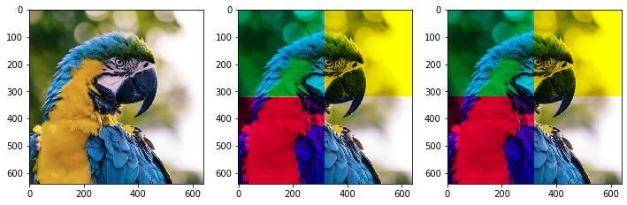

```python
# Plotting the results in separate subplots

plt.figure(figsize=(12, 6))

plt.subplot(1, 3, 1)  # create (1x3) subplots, indexing from 1
plt.imshow(img)       # original image

plt.subplot(1, 3, 2)
plt.imshow(image_iterative)

plt.subplot(1, 3, 3)
plt.imshow(image_vectorized)

plt.show()            # displays the subplots

plt.imsave('multicolor_macaw.png', image_vectorized) # saving an image
```

## Problem 2: Further Image Manipulation (7 points)

In this problem, you will solve a jigsaw puzzle given by the `jigsaw.png` image provided with the assignment. Note that the TAs have created the puzzle specifically for this class, meaning the solution will be a hopefully recognizable man (hint: a `_____`-man!). There are a total of nine jigsaw pieces of size 256x256x3, which together form a 768x768x3 image. There are three types of transformations on the pieces that you will need to resolve:

- First, the pieces are jumbled spatially.
- Second, some of the pieces are rotated (by either 90, 180, or 270 degrees).
- And third, some of the pieces have had their channels swapped from RGB to BGR.

```
Image shape: (768, 768, 3)
```

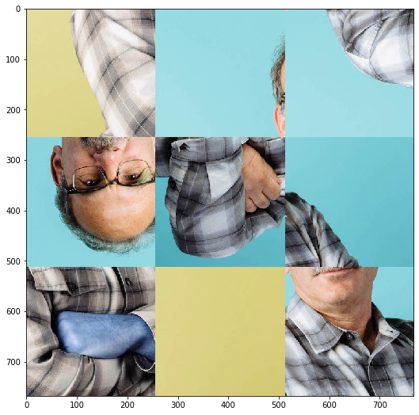

```python
import numpy as np
import matplotlib.pyplot as plt
import copy
plt.rcParams['image.cmap'] = 'gray'  # necessary to override default matplotlib behaviour

%matplotlib inline

# Read the image
jigsaw = plt.imread('jigsaw.png')
print('Image shape: %r' % (jigsaw.shape,))

# Display the image
plt.figure(figsize=(9, 9))
plt.imshow(jigsaw)
plt.show()
```

```python
# Implement each of the following four helper functions

def get_tile(image, row_index, col_index, tile_size):
    """This function returns a particular square tile of the image.

    (ROW_INDEX, COL_INDEX) describes the location of the tile in the image.

    - For example, the (0, 0) tile is the top-left tile,
      the (0, 1) tile is the tile to the right of the top-left tile,
      and the (1, 0) tile is the tile directly below the top-left tile.

    TILE_SIZE is the side length of each square tile.

    - For example, if TILE_SIZE is 256, then the (0, 1) tile
      will be the tile with indices on the vertical axis from 0 to 255,
      and with indices on the horizontal axis from 256 to 511.
    """
    height, width = image.shape[:2]
    assert tile_size <= height and tile_size <= width

    """YOUR CODE HERE; you may delete and replace the code below"""

    yourTile = np.zeros((tile_size, tile_size, 3))

    rowStart, rowStop = row_index*tile_size, (row_index+1)*tile_size
    colStart, colStop = col_index*tile_size, (col_index+1)*tile_size
    yourTile[0:tile_size, 0:tile_size, 0:3] = image[rowStart:rowStop, colStart:colStop, 0:3]

    return yourTile



def RGBtoBGR(image):
    """This function swaps the first and last channels in the color image.
    For example, if the image is originally formatted as an RGB image, the result will be a BGR image.
    And vice-versa: this function is its own inverse, and will also perform the BGR -> RGB conversion.

    You may assume that the image has three channels.
    If the input image is of shape (h, w, 3), then the return value will also be of shape (h, w, 3).
    """
    assert len(image.shape) == 3, 'the image must have a channel dimension'
    assert image.shape[-1] == 3, 'the image must have three channels'
    image = copy.deepcopy(image)  # create a copy in order to ensure that the original image does not change

    """YOUR CODE HERE; you may delete and replace the code below"""

    length, width = image.shape[0], image.shape[1]
    #print(length, width)

    newImage = np.zeros((length, width, 3))
    newImage[:,:,0] = image[:,:,2]
    newImage[:,:,1] = image[:,:,1]
    newImage[:,:,2] = image[:,:,0]

    return newImage


def rotate90(image):
    """This function rotates an image 90 degrees counterclockwise.

    You may assume that the image is square.

    You may NOT use np.rot90; we would like you to implement rotation yourself using array indexing.
    Since you only need to handle a specific 90 degree rotation case, this should be doable.

    Be sure that your function rotates the image COUNTERCLOCKWISE.
    """
    image = copy.deepcopy(image)  # create a copy in order to ensure that the original image does not change
    """YOUR CODE HERE; you may delete and replace the code below"""

    #slice each color and rotate
    tempAxisR = np.zeros((256,256))
    tempAxisG = np.zeros((256,256))
    tempAxisB = np.zeros((256,256))
    tempAxisR = image[:,:,0]
    tempAxisB = image[:,:,1]
    tempAxisG = image[:,:,2]
    tempAxisR = np.flip(tempAxisR.T,0)
    tempAxisB = np.flip(tempAxisB.T,0)
    tempAxisG = np.flip(tempAxisG.T,0)
    #reasssemble the image matrix
    newImage = np.zeros((256,256,3))
    newImage[:,:,0] = tempAxisR
    newImage[:,:,1] = tempAxisB
    newImage[:,:,2] = tempAxisG
    #print(tempAxisR.shape)
    return newImage


def replace_tile(image, row_index, col_index, tile):
    """This function replaces the existing tile at (ROW_INDEX, COL_INDEX) with the provided tile.
    You will use this to put together the final puzzle solution.

    (ROW_INDEX, COL_INDEX) describes the location of the tile to replace.
    You may assume that the tile size is given by the shape of the TILE argument.

    Replace whatever is already at the tile position with the passed-in TILE.
    Then return the modified full image (we are doing this in a non-destructive way).
    """
    image = copy.deepcopy(image)  # create a copy in order to ensure that the original image does not change

    """YOUR CODE HERE; you may delete and replace the code below"""

    tile_size = tile.shape[0]
    image[row_index*tile_size:(row_index+1)*tile_size, col_index*tile_size:(col_index+1)*tile_size, :] = tile
    return image
```

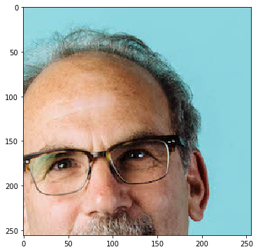

```
(256, 256, 3)
```

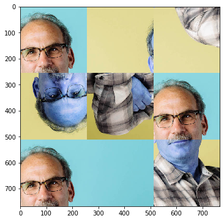

```python
### TEST CELL ###

tileTest = get_tile(jigsaw, 1, 0, 256)
tileTest = RGBtoBGR(tileTest)
tileTest = RGBtoBGR(tileTest)
tileTest = rotate90(tileTest)
tileTest = rotate90(tileTest)
plt.figure(figsize=(6, 6))
plt.imshow(tileTest)
plt.show()
print(tileTest.shape)
#newImage = np.zeros((256, 256, 3))
#print(newImage)
newImage = RGBtoBGR(jigsaw)
swappedImage = newImage
swappedImage = replace_tile(swappedImage, 0, 0, tileTest)
swappedImage = replace_tile(swappedImage, 1, 2, tileTest)
swappedImage = replace_tile(swappedImage, 2, 0, tileTest)
plt.figure(figsize=(6, 6))
plt.imshow(swappedImage)
plt.show()
```

Now you must use the helper functions you just implemented in order to solve the jigsaw puzzle. When you're finished, display your result!

Note: just to be clear, you are not expected to write general code to solve arbitrary jigsaw puzzle problems. You only need to solve this one in particular (and this is just meant to be a fun exercise in basic image manipulation operations). Thus, all you need to do is hardcode the transformations for this puzzle. There's no need to (for example) search over the space of transformations and select the best ones based on consistency between different boundaries.

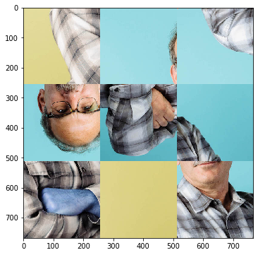

```python
# For reference, here is the jigsaw puzzle again

plt.figure(figsize=(6, 6))
plt.imshow(jigsaw)
plt.show()
```

```
My jigsaw solution
```

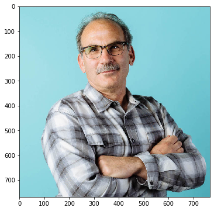

```python
# Solve the jigsaw puzzle

tile_size = 256

# Extract tiles
# Note: the tile named "tileIJ" refers to the tile at row I and column J
tile00 = get_tile(jigsaw, 0, 0, tile_size)
tile01 = get_tile(jigsaw, 0, 1, tile_size)
tile02 = get_tile(jigsaw, 0, 2, tile_size)

tile10 = get_tile(jigsaw, 1, 0, tile_size)
tile11 = get_tile(jigsaw, 1, 1, tile_size)
tile12 = get_tile(jigsaw, 1, 2, tile_size)

tile20 = get_tile(jigsaw, 2, 0, tile_size)
tile21 = get_tile(jigsaw, 2, 1, tile_size)
tile22 = get_tile(jigsaw, 2, 2, tile_size)

# Transform tiles as necessary
# You will want to use RGBtoBGR and rotate90.
# Hint: three tiles are rotated, and three (different) tiles have been switched from RGB to BGR.
"""YOUR CODE HERE"""
tile00 = RGBtoBGR(tile00)
tile20 = RGBtoBGR(tile20)
tile21 = RGBtoBGR(tile21)

tile10 = rotate90(rotate90(tile10))
tile11 = rotate90(tile11)
tile02 = rotate90(rotate90(rotate90(tile02)))


solution = np.zeros_like(jigsaw)
# Place tiles in their proper position in the solution image
"""YOUR CODE HERE; modify the row_index and col_index arguments to the `replace_tile` calls"""

solution = replace_tile(solution, 2, 0, tile00)
solution = replace_tile(solution, 0, 0, tile01)
solution = replace_tile(solution, 1, 0, tile02)#####

solution = replace_tile(solution, 0, 1, tile10)
solution = replace_tile(solution, 2, 2, tile11)
solution = replace_tile(solution, 1, 2, tile12)

solution = replace_tile(solution, 2, 1, tile20)
solution = replace_tile(solution, 0, 2, tile21)
solution = replace_tile(solution, 1, 1, tile22)

print('My jigsaw solution')
plt.figure(figsize=(6, 6))
plt.imshow(solution)
plt.show()
```

## Problem 3: Mathematics Background Check (3 points)

The last part of this homework is a review of the math prerequisites in order to make sure you're prepared for the rest of the course. The topics include linear algebra, probability, and calculus. You should make a solid attempt at every question, but you don't need to get every question correct to get full credit. In fact, this problem will be graded based on effort. We just want you to use this section as review, and perhaps as a diagnostic check as well.

To submit your answers to this problem, you can scan your handwritten work and include it in the PDF, or create a Markdown cell below to answer each of the problems (possibly using LaTeX wherever it is helpful; note that you can use LaTeX in a Markdown cell with `$...$` syntax for inline math, and `$$...$$` syntax for non-inline math).

You may find the following resources helpful for this part:

- [Linear algebra review](http://www.cse.ucsd.edu/classes/fa11/cse252A-a/linear_algebra_review.pdf)
- [Random variables review](http://www.cse.ucsd.edu/classes/fa11/cse252A-a/random_var_review.pdf)

### Part 1: Linear Algebra

1. Consider the following vectors: $\mathbf{v}_{1}=\begin{bmatrix}{1} \\ {-1} \\ {2}\end{bmatrix}, \mathbf{v}_{2}=\begin{bmatrix}{0} \\ {1} \\ {-1}\end{bmatrix}, \mathbf{v}_{3}=\begin{bmatrix}{2} \\ {-3}\end{bmatrix}, \mathbf{v}_{4}=\begin{bmatrix}{0} \\ {1} \\ {-5}\end{bmatrix}$
   1. What is $\mathbf{v}_{1} + \mathbf{v}_{2}$?
   2. What is $\mathbf{v}_{1} \bullet \mathbf{v}_{2}$?
   3. What is $\mathbf{v}_{1} \times \mathbf{v}_{2}$?
   4. Express the dot product from B in terms of matrix multiplication.
   5. Explain why $\mathbf{v}_{3} \bullet \mathbf{v}_{4}$ is not defined.
2. Consider the following matrices: $A=\left[\begin{array}{ll}{1} & {2} \\ {3} & {3}\end{array}\right], B=\left[\begin{array}{ll}{1} & {2} \\ {2} & {4}\end{array}\right]$
   1. What is the transpose of A? Is A symmetric? Is B symmetric?
   2. What is the rank of B?
   3. What is the determinant of A?
   4. What is the trace of A?
   5. Is B invertible? How many linearly independent columns does B have?
   6. What is the nullspace of B? What is its dimension?
   7. Write the general form of a 2x2 rotation matrix. Denote this as R.
      1. What is its determinant?
      2. What is $R^{T}R$?
   8. Does the equation $Ax = b$ have a solution for all $b$? Can you say the same for the equation $Bx = b$?
3. Consider the matrix $C=\left[\begin{array}{ll}{1} & {6} \\ {1} & {2}\end{array}\right]$
   1. What are the eigenvalues and eigenvectors of C?

### Part 2: Calculus

1. Note the following definitions and answer the questions below.  
   $\mathbf{x} = \begin{bmatrix}{x_{1}} \\ {x_{2}}\end{bmatrix}, \quad f(\mathbf{x})=x_{1}^{2}x_{2}, \quad g(y)=y^{3} + 2y^{2}, \quad h(x) = \sin(x)$
   1. What is the gradient of $f(\mathbf{x})$?
   2. What is the Hessian of $f(\mathbf{x})$?
   3. What are the local minimum and maxima of $g(y)$?
   4. What is the derivative of $(h \circ g)(y)$ w.r.t $y$?

### Part 3: Probability

1. Let $A$ and $B$ be two random events with $P(A) = x, P(B) = y$.
   1. Assume $A$ and $B$ are independent events. Now answer the following questions.
      1. What is $P(A|B)$?
      2. What is $P(AB)$?
      3. What is $P(A \cup B)$
   2. Now answer the same questions given that $A$ and $B$ are mutually exclusive.
2. Let $X$ be a random event with $E(X) = 0.2$ and $E(X^{2}) = 0.5$. What is the variance of $X$?

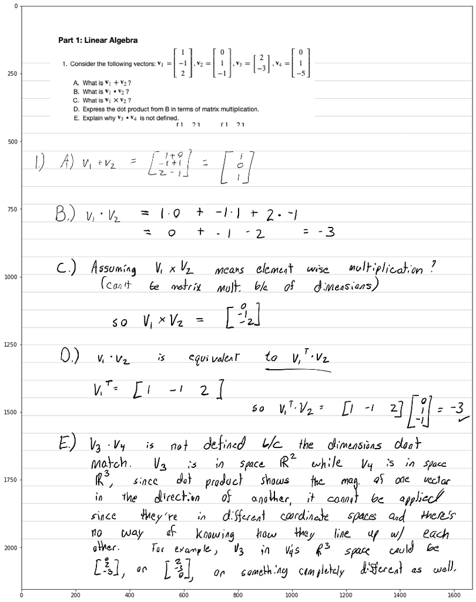

```python
WrittenOne = plt.imread('CSE 252A HW0 Written-3.jpg')             # read a JPEG image

plt.figure(figsize=(20, 20))
plt.imshow(WrittenOne)                           # displaying the original image
plt.show()
```

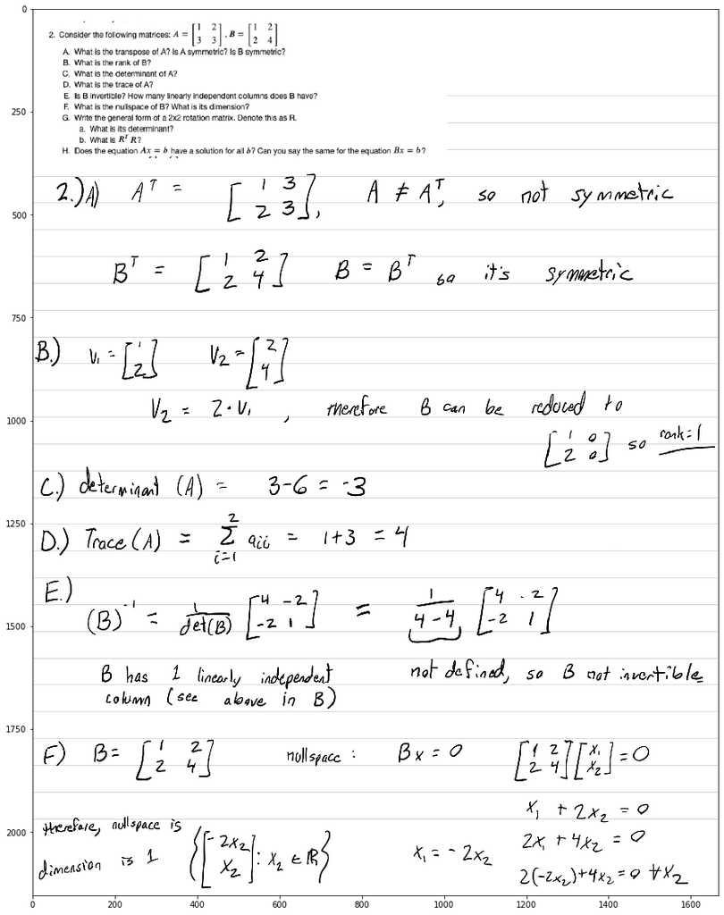

```python
WrittenTwo = plt.imread('CSE 252A HW0 Written-4.jpg')             # read a JPEG image

plt.figure(figsize=(20, 20))
plt.imshow(WrittenTwo)                           # displaying the original image
plt.show()
```

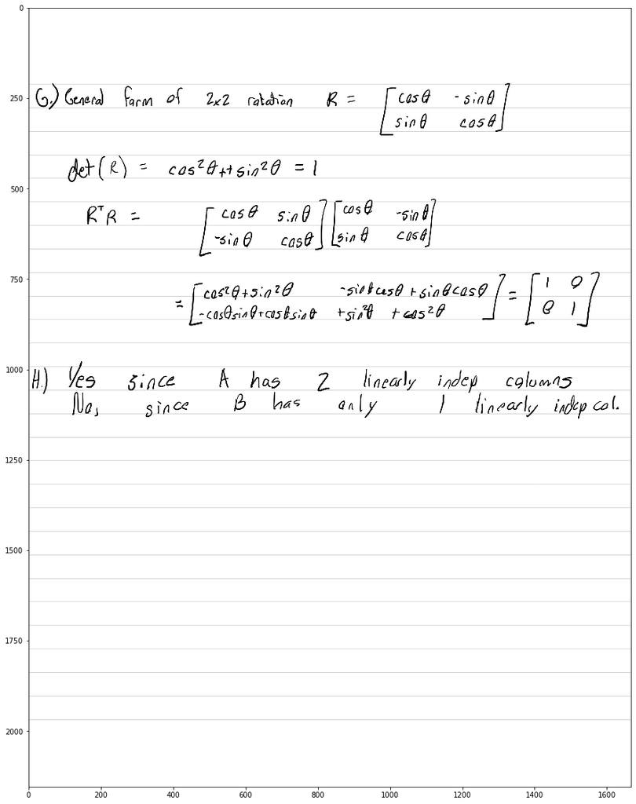

```python
WrittenThree = plt.imread('CSE 252A HW0 Written-5.jpg')             # read a JPEG image

plt.figure(figsize=(20, 20))
plt.imshow(WrittenThree)                           # displaying the original image
plt.show()
```

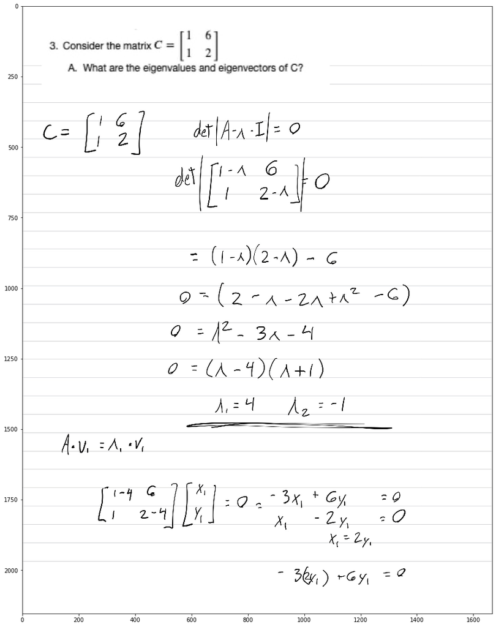

```python
WrittenFour = plt.imread('CSE 252A HW0 Written-6.jpg')             # read a JPEG image

plt.figure(figsize=(20, 20))
plt.imshow(WrittenFour)                           # displaying the original image
plt.show()
```

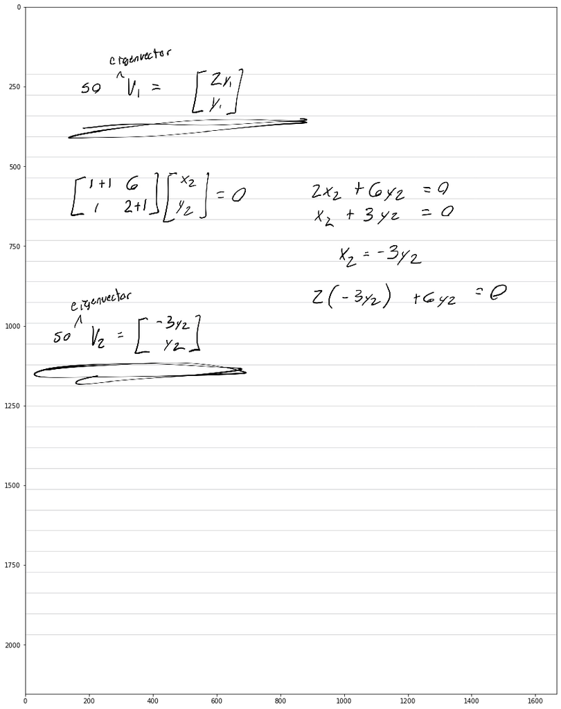

```python
WrittenFive = plt.imread('CSE 252A HW0 Written-7.jpg')             # read a JPEG image

plt.figure(figsize=(20, 20))
plt.imshow(WrittenFive)                           # displaying the original image
plt.show()
```

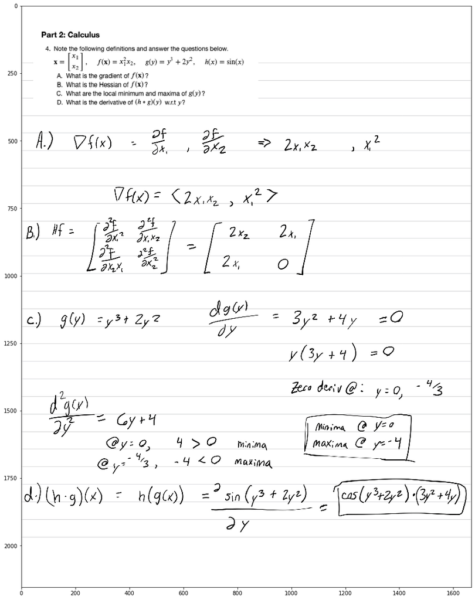

```python
WrittenSix = plt.imread('CSE 252A HW0 Written-8.jpg')             # read a JPEG image

plt.figure(figsize=(20, 20))
plt.imshow(WrittenSix)                           # displaying the original image
plt.show()
```

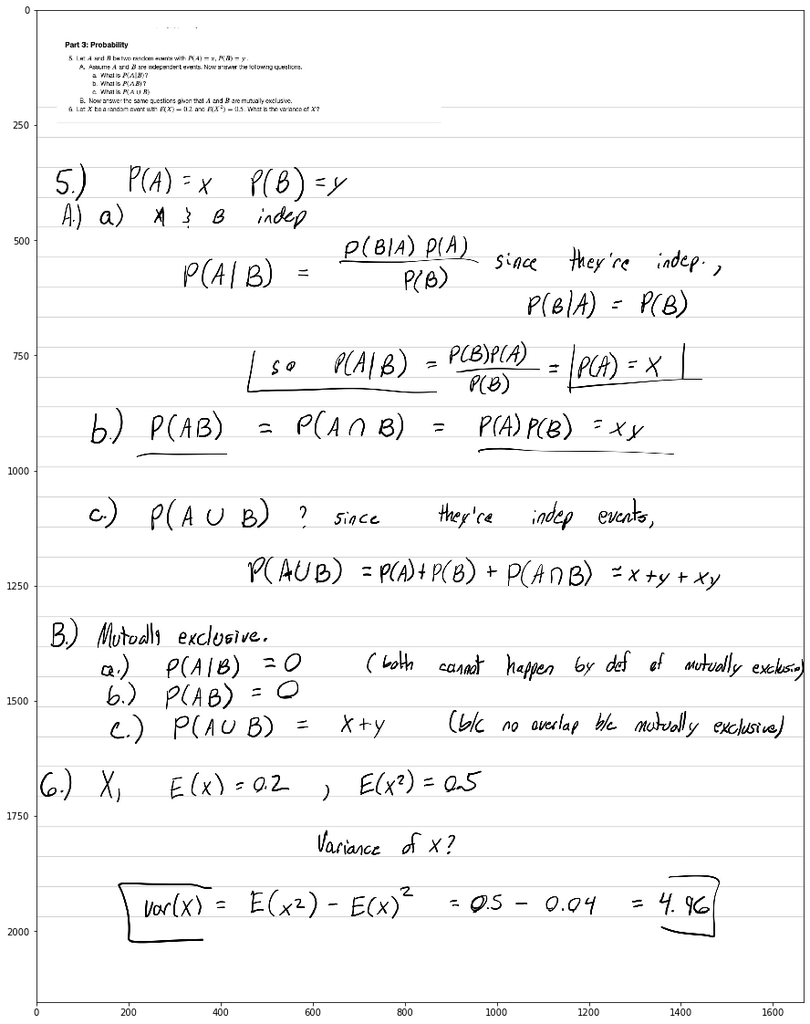

```python
WrittenSeven = plt.imread('CSE 252A HW0 Written-9.jpg')             # read a JPEG image

plt.figure(figsize=(20, 20))
plt.imshow(WrittenSeven)                           # displaying the original image
plt.show()
```

### Submission Instructions

Remember to submit a PDF version of this notebook to Gradescope. You can create a PDF via **File > Download as > PDF via LaTeX** (preferred, if possible), or by downloading as an HTML page and then "printing" the HTML page to a PDF (by opening the print dialog and then choosing the "Save as PDF" option).